# ME 2061: Reduced Order Modeling

## Homework 1

*Author: Jacob Cunningham*

*Source code: [GitHub Repo](https://github.com/GoogleTookMyLunch/ME_2061/tree/main/homework)*

1. [Problem 1](#Problem-1)

2. [Problem 2](#Problem-2)

3. [Problem 3](#Problem-3)

4. [Problem 4](#Problem-4)

### Notes

Please consider viewing the source Juypter notebook located in the GitHub Repository (https://github.com/GoogleTookMyLunch/ME_2061/tree/main/homework); converting it to pdf and viewing it as such can lead to sub-optimal formatting.

**Final answers are formatted like this.**

### Problem 1

Determine which of the following sets are linearly independent. For those sets that are linearly dependent, write one of the vectors as a linear combination of the others.

1.  $ \begin{bmatrix} \begin{pmatrix} 1\\ 2\\ 3 \end{pmatrix} \text{,} \begin{pmatrix} 2\\ 1\\ 0 \end{pmatrix} \text{,} \begin{pmatrix} 1\\ 5\\ 9 \end{pmatrix} \end{bmatrix} $  
2.  $ \begin{bmatrix} \begin{pmatrix} 1\\ 2\\ 0\\ 4\\ 0\\ 3\\ 0 \end{pmatrix} \text{,} \begin{pmatrix} 0\\ 2\\ 0\\ 4\\ 1\\ 3\\ 0 \end{pmatrix} \text{,} \begin{pmatrix} 0\\ 2\\ 1\\ 4\\ 0\\ 3\\ 0 \end{pmatrix} \text{,} \begin{pmatrix} 0\\ 2\\ 0\\ 4\\ 0\\ 3\\ 1 \end{pmatrix} \end{bmatrix} $

#### Problem 1 calculations

From [Strang, Gilbert. Introduction to Linear Algebra. Wellesley, Ma, Cambridge Press, 2016](https://math.mit.edu/~gs/linearalgebra/ila5/indexila5.html), given $\mathbf{u}\text{, }\mathbf{v}\text{, }\mathbf{w}$ which occupy space in $\mathbb{R}^n$:

- $\mathbf{u}\text{, }\mathbf{v}\text{, }\mathbf{w}$ are linearly independent if no other linear combination except $0\mathbf{u} + 0\mathbf{v} + 0\mathbf{w} = \mathbf{0}$
- Otherwise the vectors are linearly dependent

**1.**  
Given:

$$ \begin{bmatrix} \begin{pmatrix} 1\\ 2\\ 3 \end{pmatrix} \text{,} \begin{pmatrix} 2\\ 1\\ 0 \end{pmatrix} \text{,} \begin{pmatrix} 1\\ 5\\ 9 \end{pmatrix} \end{bmatrix} $$

let:

$$ \qquad \mathbf{u} = \begin{pmatrix}1\\2\\3\end{pmatrix}\text{,} \qquad \mathbf{v} = \begin{pmatrix}2\\1\\0\end{pmatrix}\text{,} \qquad \mathbf{w} = \begin{pmatrix}1\\5\\9\end{pmatrix}\text{,} \qquad \mathbf{b} = \begin{pmatrix}0\\0\\0\end{pmatrix}\text{,} \qquad \text{and } c\text{, }d\text{, }e \in{} \mathbb{R} $$

The set of all linear combinations can be written as $c\mathbf{u} + d\mathbf{v} + e\mathbf{w}$

Since $\mathbf{Ax}$ is the linear combination of the columns of $\mathbf{A}$, let:

$$ \mathbf{Ax} = \begin{bmatrix} 1 & 2 & 1 \\ 2 & 1 & 5 \\ 3 & 0 & 9 \end{bmatrix} \begin{bmatrix} c\\ d\\ e \end{bmatrix} $$

Setting $\mathbf{Ax} = \mathbf{b}$:

$$ \begin{bmatrix} 1 & 2 & 1 \\ 2 & 1 & 5 \\ 3 & 0 & 9 \end{bmatrix} \begin{bmatrix} c\\ d\\ e \end{bmatrix} = \begin{bmatrix} 0\\ 0\\ 0 \end{bmatrix} $$

And performing Guassian Elimination:

$$ \left[\begin{array}{rrr|r} 1 & 2 & 1 & 0 \\ 2 & 1 & 5 & 0 \\ 3 & 0 & 9 & 0 \end{array}\right] $$$$ \left[\begin{array}{rrr|r} 1 & 2 & 1 & 0 \\ 0 & -3 & 3 & 0 \\ 3 & 0 & 9 & 0 \end{array}\right] $$$$ \left[\begin{array}{rrr|r} 1 & 2 & 1 & 0 \\ 0 & -3 & 3 & 0 \\ 0 & -6 & 6 & 0 \end{array}\right] $$$$ \left[\begin{array}{rrr|r} 1 & 2 & 1 & 0 \\ 0 & 0 & 0 & 0 \\ 0 & 1 & -1 & 0 \end{array}\right] $$

Row reduced echelon form:

Let $c = 3$ then:

$$ 3 \begin{bmatrix} 1 \\ 2 \\ 3 \\ \end{bmatrix} - 1 \begin{bmatrix} 2 \\ 1 \\ 0 \end{bmatrix} - 1 \begin{bmatrix} 1 \\ 5 \\ 9 \end{bmatrix} = \begin{bmatrix} 3 - 2 - 1 \\ 6 - 1 - 5 \\ 9 - 0 - 9 \end{bmatrix} = \begin{bmatrix} 0 \\ 0 \\ 0 \end{bmatrix} $$

**Therefore the set of vectors are linearly dependent**

Vector $\mathbf{w}$ can be written as a combination of vectors $\mathbf{u}$ and $\mathbf{v}$ as shown below:

$$ 3\mathbf{u} - \mathbf{v} = \mathbf{w} $$

Given $ \qquad \begin{bmatrix} \begin{pmatrix} 1\\ 2\\ 0\\ 4\\ 0\\ 3\\ 0 \end{pmatrix} \text{,} \begin{pmatrix} 0\\ 2\\ 0\\ 4\\ 1\\ 3\\ 0 \end{pmatrix} \text{,} \begin{pmatrix} 0\\ 2\\ 1\\ 4\\ 0\\ 3\\ 0 \end{pmatrix} \text{,} \begin{pmatrix} 0\\ 2\\ 0\\ 4\\ 0\\ 3\\ 1 \end{pmatrix} \end{bmatrix} $
let: $ \qquad \mathbf{u} = \begin{pmatrix}1\\2\\0\\4\\0\\3\\0\end{pmatrix}\text{,} \qquad \mathbf{v} = \begin{pmatrix}0\\2\\0\\4\\1\\3\\0\end{pmatrix}\text{,} \qquad \mathbf{w} = \begin{pmatrix}0\\2\\1\\4\\0\\3\\0\end{pmatrix}\text{,} \qquad \mathbf{a} = \begin{pmatrix}0\\2\\1\\4\\0\\3\\0\end{pmatrix}\text{,} \qquad \mathbf{b} = \begin{pmatrix}0\\0\\0\\0\\0\\0\\0\end{pmatrix}\text{,} \qquad \text{and } c\text{, }d\text{, }e\text{, } f \in{} \mathbb{R} $
Following the same procedure as before... $$ \left[\begin{array}{rrrr|r} 1 & 0 & 0 & 0 & 0 \\ 2 & 2 & 2 & 2 & 0 \\ 0 & 0 & 1 & 0 & 0 \\ 4 & 4 & 4 & 4 & 0 \\ 0 & 1 & 0 & 0 & 0 \\ 3 & 3 & 3 & 3 & 0 \\ 0 & 0 & 0 & 1 & 0 \end{array}\right] $$ $$ \left[\begin{array}{rrrr|r} 1 & 0 & 0 & 0 & 0 \\ 1 & 1 & 1 & 1 & 0 \\ 0 & 0 & 1 & 0 & 0 \\ 1 & 1 & 1 & 1 & 0 \\ 0 & 1 & 0 & 0 & 0 \\ 1 & 1 & 1 & 1 & 0 \\ 0 & 0 & 0 & 1 & 0 \end{array}\right] $$ $$ \left[\begin{array}{rrrr|r} 1 & 0 & 0 & 0 & 0 \\ 0 & 1 & 0 & 0 & 0 \\ 0 & 0 & 1 & 0 & 0 \\ 0 & 0 & 0 & 1 & 0 \\ 1 & 1 & 1 & 1 & 0 \\ 1 & 1 & 1 & 1 & 0 \\ 1 & 1 & 1 & 1 & 0 \end{array}\right] $$ $$ \left[\begin{array}{rrrr|r} 1 & 0 & 0 & 0 & 0 \\ 0 & 1 & 0 & 0 & 0 \\ 0 & 0 & 1 & 0 & 0 \\ 0 & 0 & 0 & 1 & 0 \\ 0 & 0 & 0 & 0 & 0 \\ 0 & 0 & 0 & 0 & 0 \\ 0 & 0 & 0 & 0 & 0 \end{array}\right] $$ $$ \begin{bmatrix} 1 & 0 & 0 & 0 \\ 0 & 1 & 0 & 0 \\ 0 & 0 & 1 & 0 \\ 0 & 0 & 0 & 1 \end{bmatrix} \begin{bmatrix} c \\ d \\ e \\ f \end{bmatrix} = \begin{bmatrix} c \\ d \\ e \\ f \end{bmatrix} = \begin{bmatrix} 0 \\ 0 \\ 0 \\ 0 \end{bmatrix} $$ $c = d = e = f = 0$

**Therefore the set of vectors are linearly independent**

### Problem 2

Which of the following sets of functions are linearly dependent?

1. {$\sin{x}\text{, }\cos{x}\text{, }x\sin{x}$}
2. {$\exp{x}\text{, }x\exp{x}\text{, }x^{2}\exp{x}$}
3. {$\sin^{2}{x}\text{, }\cos^{2}{x}\text{, }\cos{2x}$}

#### Problem 2 calculations

Suppose $(a, b, c) \in \mathbb{R}$. From LibreTexts Mathematics:

> Let $f(t)$f and $g(t)$ be differentiable functions. Then they are called *linearly dependent* if there are nonzero constants $c_1$ and $c_2$ with $c_{1}f(t) + c_{2}g(t) = 0$ for all $t$. Otherwise they are called *linearly independent*.

```python
# import necessary modules
from sympy import *

# define symbols
x = Symbol('x')

# define functions
f1 = sin(x)
f2 = cos(x)
f3 = x*sin(x)

# calculate first derivatives
d_f1 = f1.diff(x)
d_f2 = f2.diff(x)
d_f3 = f3.diff(x)

# calculate second derivatives
d2_f1 = d_f1.diff(x)
d2_f2 = d_f2.diff(x)
d2_f3 = d_f3.diff(x)

# create a symbolic matrix
sym_mat = Matrix([[f1, f2, f3], [d_f1, d_f2, d_f3], [d2_f1, d2_f2, d2_f3]])

# calculate the Wronskian
wronskian = sym_mat.det()

# print the result
print(f"The Wronskian is: {wronskian}")
```

```
The Wronskian is: -2*sin(x)**2*cos(x) - 2*cos(x)**3
```

The Wronskian for the system of equations is $W = -2\sin{x}^{2}\cos{x}-2\cos{x}^{3}$. Given this result is cyclic on the interval $I = [0, 2\pi{}]$, plotting the Wronskian over that domain will indicate if the result is nonzero.

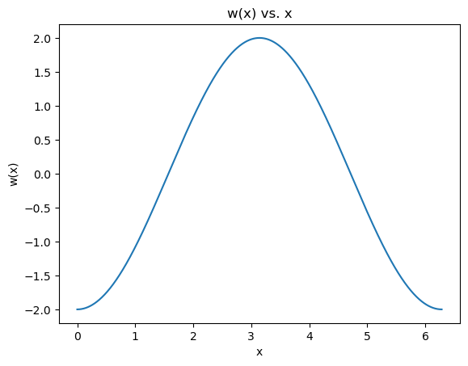

```python
# import necessary modules
import numpy as np
import matplotlib.pyplot as plt

# define domain and range
x = np.arange(0,2*np.pi, 0.001)
w = -2*np.sin(x)**2*np.cos(x)-2*np.cos(x)**3

# map the domain to the range
plt.plot(x, w)
plt.title("w(x) vs. x")
plt.xlabel("x")
plt.ylabel("w(x)")
plt.show()
```

```python
# import necessary modules
from sympy import *

# define the symbols
x = Symbol('x')

# define the equation
wronskian_eq = Eq(-2*sin(x)**2*cos(x) - 2*cos(x)**3, 0)

# solve the equation over the domain
sols = solve(wronskian_eq, x, domain=(0, 2*pi))

# print the results
print(f"Solutions: {sols}")
```

```
Solutions: [-pi/2, pi/2]
```

Returning to the original definition of $c_{1}f(t) + c_{2}g(t) = 0$, let $a\sin{x} + b\cos{x} + cx\sin{x} = 0$. Given that $cx$ is another constant, then $cx\sin{x}$ is clearly just a multiple of $a\sin{x}$.

**2.**  
{$\exp{x}\text{, }x\exp{x}\text{, }x^{2}\exp{x}$}  
Returning to the original definition of $c_{1}f(t) + c_{2}g(t) = 0$, let $a\exp{x} + bx\exp{x} + cx^{2}\exp{x} = 0$. Given that $bx$ is another constant, then $bx\exp{x}$ is clearly just a multiple of $a\exp{x}$.

**Therefore the set of functions are linearly dependent**

**2.**  
{$\sin^{2}{x}\text{, }\cos^{2}{x}\text{, }\cos{2x}$}

```python
# import necessary modules
from sympy import *

# define symbols
x = Symbol('x')

# define functions
f1 = sin(x)**2
f2 = cos(x)**2
f3 = sin(2*x)

# calculate first derivatives
d_f1 = f1.diff(x)
d_f2 = f2.diff(x)
d_f3 = f3.diff(x)

# calculate second derivatives
d2_f1 = d_f1.diff(x)
d2_f2 = d_f2.diff(x)
d2_f3 = d_f3.diff(x)

# create a symbolic matrix
sym_mat = Matrix([[f1, f2, f3], [d_f1, d_f2, d_f3], [d2_f1, d2_f2, d2_f3]])

# calculate the Wronskian
wronskian = sym_mat.det()

# print the result
print(f"The Wronskian is: {wronskian}")
```

```
The Wronskian is: -4*sin(x)**4*cos(2*x) + 8*sin(x)**3*sin(2*x)*cos(x) + 8*sin(x)*sin(2*x)*cos(x)**3 + 4*cos(x)**4*cos(2*x)
```

The Wronskian for the system of equations is
$$ W = -4\sin^{4}{x}\cos{2x} + 8\sin^{3}{x}\sin{2x}\cos{x} + 8\sin{x}\sin{2x}\cos^{3}{x} + 4\cos^{4}{x}\cos{2x} $$
Given this result is cyclic on the interval $I = [0, 2\pi{}]$, plotting the Wronskian over that domain will indicate if the result is nonzero.

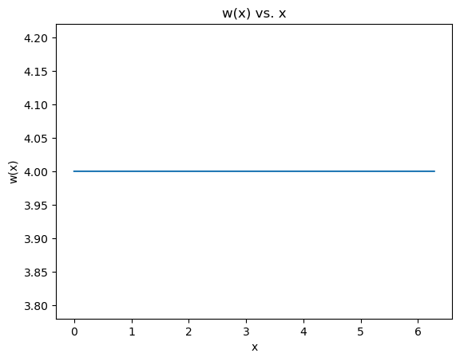

```python
# import necessary modules
import numpy as np
import matplotlib.pyplot as plt

# define domain and range
x = np.arange(0,2*np.pi, 0.001)
w = -4*np.sin(x)**4*np.cos(2*x) + 8*np.sin(x)**3*np.sin(2*x)*np.cos(x) + 8*np.sin(x)*np.sin(2*x)*np.cos(x)**3 + 4*np.cos(x)**4*np.cos(2*x)

# map the domain to the range
plt.plot(x, w)
plt.title("w(x) vs. x")
plt.xlabel("x")
plt.ylabel("w(x)")
plt.show()
```

The Wronskian is never zero over the interval.

### Problem 3

For $ x = \begin{bmatrix} x_1 \\ x_2 \\ x_3 \end{bmatrix} \text{, } y = \begin{bmatrix} y_1 \\ y_2 \\ y_3 \end{bmatrix} $ , determine which of the following are inner products for $\mathbb{R}^{3}$.

1. $\langle\mathbf{x}\text{, }\mathbf{y}\rangle = x_{1}y_{1} + x_{3}y_{3}$
2. $\langle\mathbf{x}\text{, }\mathbf{y}\rangle = x_{1}y_{1} - x_{2}y_{2} + x_{3}y_{3}$
3. $\langle\mathbf{x}\text{, }\mathbf{y}\rangle = 2x_{1}y_{1} + x_{2}y_{2} + 4x_{3}y_{3}$
4. $\langle\mathbf{x}\text{, }\mathbf{y}\rangle = x^{2}_{1}y^{2}_{1} + x^{2}_{2}y^{2}_{2} + x^{2}_{3}y^{2}_{3}$

#### Problem 3 calculations

From this reference:

> **Definition**: Let $V$ be a vector space over $F$, where $F = \mathbb{R}\text{ or }\mathbb{C}$. An inner product on $V$ is a function $\langle\cdot\text{,}\cdot\rangle\text{: }V \times{} V\rightarrow F$ which satisifies:  
> 1. Linearity: $\langle{}ax+y\text{, }z\rangle = a\langle{}x\text{, }z\rangle + \langle{}y\text{, }z\rangle\text{ for }x\text{, }y\text{, z}\in V\text{, }a \in F$
> 1. Symmetry: $\langle{}x\text{, }y\rangle = \overline{\langle{}y\text{, }x\rangle}\text{, for }x\text{, }y \in V$
> 2. Positive-definiteness: If $x\neq 0\text{, then }\langle{}x\text{, }x\rangle \in \mathbb{R} \text{ and }\langle{}x\text{, }x\rangle\gt 0$

**1.**
$$ \langle\mathbf{x}\text{, }\mathbf{y}\rangle = x_{1}y_{1} + x_{3}y_{3} $$

Check for linearity in the first slot, we don't have to check the second slot because we'll check for symmetry if this property holds:

Since $a\langle{}x\text{, }y\rangle = \langle{}ax\text{, }y\rangle$ to ensure linearity of the entire inner product space...

$$ \begin{align} \langle{}ax\text{, }y\rangle & = a(x_{1}y_{1} + x_{3}y_{3})\\ & = ax_{1}y_{1} + ax_{3}y_{3} \end{align} $$

As long as the property $a\langle{}x\text{, }y\rangle = \langle{}ax\text{, }y\rangle$ holds true, then scaler multiplication is satisifed.

Checking for additivity:

$$ \begin{align} \langle{}x_1 + x_2\text{, }y\rangle &= (x_1 + x_2)y_1 + x_{3}y_{3}\\ & = x_{1}y_{1} + x_{2}y_{1} + x_{3}y_{3}\\ \end{align} $$

From the inner product property $\langle{}x_1 + x_2\text{, }y\rangle = \langle{}x_1\text{, }y\rangle{} + \langle{x_2}\text{, }y\rangle$

$$ \langle{}x_1\text{, }y\rangle + \langle{}x_2\text{, }y\rangle = x_{1}y_{1} + x_{3}y_{3} + x_{2}y_{1} + x_{3}y_{3} $$

Since:

$$ \begin{align} x_{1}y_{1} + x_{2}y_{1} + x_{3}y_{3} & \neq x_{1}y_{1} + x_{3}y_{3} + x_{2}y_{1} + x_{3}y_{3}\\ \langle{}x_1 + x_{2}\text{, }y\rangle & \neq \langle{}x_1\text{, }y\rangle + \langle{}x_{2}\text{, }y\rangle \end{align} $$

**Therefore this is not an inner product space for $\mathbb{R}^3$**

**2.**
$$ \langle\mathbf{x}\text{, }\mathbf{y}\rangle = x_{1}y_{1} - x_{2}y_{2} + x_{3}y_{3} $$

Checking for scaler multiplicity:

$$ \begin{align} \langle{}ax\text{, }y\rangle & = ax_{1}y_1 - ax_{2}y_2 + ax_{3}y_3\\ & =a\langle{}x\text{, }y\rangle \\ & = a(x_{1}y_1 - x_{2}y_2 + x_{3}y_3) \end{align} $$

Therefore scaler multiplicity is satisifed.

Checking for additivity:

$$ \begin{align} \langle{}x_1 + x_2\text{, }y\rangle & = (x_1 + x_2)y_1 - (x_1 +x_2)y_2 + (x_1 + x_2)y_3\\ & = x_{1}y_1 + x_{2}y_1 - x_{1}y_2 - x_{2}y_2 + x_{1}y_3 + x_{2}y_3\\ & = \langle{}x_1\text{, }y\rangle + \langle{}x_2\text{, }y\rangle\\ & = (x_{1}y_1 - x_{1}y_2 + x_{1}y_3) + (x_{2}y_1 - x_{2}y_2 + x_{2}y_3) \\ & = x_{1}y_1 + x_{2}y_1 - x_{1}y_2 - x_{2}y_2 + x_{1}y_3 + x_{2}y_3 \end{align} $$

Therefore additivity is satisifed.

Checking for symmetry:

$$ \begin{align} \langle{}x\text{, }y\rangle & = x_{1}y_1 - x_{2}y_2 + x_{3}y_3\\ & = \langle{}y\text{, }x\rangle \\ & = y_{1}x_1 - y_{2}x_2 + y_{3}x_3 \end{align} $$

Therefore symmetry is satisifed.

Checking for positive definiteness:

$$ \langle{}x\text{, }x\rangle = x_{1}^2 - x_{2}^2 + x{3}^2 $$

If $x_{2}^2 \gt x_{1}^{2} + x_{3}^2$ then the inner product is not positive definite.

**Therefore this is not an inner product space for $\mathbb{R}^3$**

**3.**
$$ \langle\mathbf{x}\text{, }\mathbf{y}\rangle = 2x_{1}y_{1} + x_{2}y_{2} + 4x_{3}y_{3} $$

Checking for scaler multiplicity:

$$ \begin{align} \langle{}ax\text{, }y\rangle & = 2ax_{1}y_1 + ax_{2}y_2 + 4ax_{3}y_3\\ & =a\langle{}x\text{, }y\rangle \\ & = a(2x_{1}y_1 + x_{2}y_2 + 4x_{3}y_3) \end{align} $$

Therefore scaler multiplicity is satisfied.

Checking for additivity:

$$ \begin{align} \langle{}x_1 + x_2\text{, }y\rangle & = 2(x_1 + x_2)y_1 + (x_1 + x_2)y_2 + 4(x_1 + x_2)y_3\\ & = 2x_{1}y_1 + 2x_{2}y_1 + x_{1}y_2 + x_{2}y_2 + 4x_{1}y_3 + 4x_{2}y_3\\ & = \langle{}x_1\text{, }y\rangle + \langle{}x_2\text{, }y\rangle\\ & = (2x_{1}y_1 + x_{1}y_2 + 4x_{1}y_3) + (2x_{2}y_1 + x_{2}y_2 + 4x_{2}y_3) \\ & = 2x_{1}y_1 + 2x_{2}y_1 + x_{1}y_2 + x_{2}y_2 + 4x_{1}y_3 + 4x_{2}y_3 \end{align} $$

Therefore additivity is satisifed.

Checking for symmetry:

$$ \begin{align} \langle{}x\text{, }y\rangle & = 2x_{1}y_1 + x_{2}y_2 + 4x_{3}y_3\\ & = \langle{}y\text{, }x\rangle \\ & = 2y_{1}x_1 + y_{2}x_2 + 4y_{3}x_3 \end{align} $$

Therefore symmetry is satisifed.

Checking for positive definiteness:

$$ \langle{}x\text{, }x\rangle = 2x_{1}^2 + x_{2}^2 + 4x_{3}^2 $$

This expression is equal to 0 only when $x_1 = x_2 = x_3 = 0$ and otherwise is always nonnegative so positive definiteness is satisifed.

**Therefore this is an inner product space for $\mathbb{R}^3$**

**4.**
$$ \langle\mathbf{x}\text{, }\mathbf{y}\rangle = x^{2}_{1}y^{2}_{1} + x^{2}_{2}y^{2}_{2} + x^{2}_{3}y^{2}_{3} $$

At this point for me it is clear that this inner product satisfies multiplicity, symmetry, and positive definiteness. I'll check for additivity explicitly:

$$ \begin{align} \langle{}x_1 + x_2\text{, }y\rangle & = (x_1 + x_2)^{2}y_{1}^{2} + (x_1 +x_2)^{2}y_{2}^{2} + (x_1 + x_2)^{2}y_{3}^{2}\\ & = (x_{1}^{2} + 2x_{1}x_{2} + x_{2}^{2})y_{1}^{2} + (x_{1}^{2} + 2x_{1}x_{2} + x_{2}^{2})y_{2}^{2} + (x_{1}^{2} + 2x_{1}x_{2} + x_{2}^{2})y_{3}^{2} \end{align} $$

Let $z := x_{1}^{2} + 2x_{1}x_{2} + x_{2}^{2}$, then

$$ \begin{align} \langle{}x_1 + x_2\text{, }y\rangle & = zy_{1}^{2} + zy_{2}^{2} + zy_{3}^{2} \\ & \neq \langle{}x_1\text{, }y\rangle + \langle{}x_2\text{, }y\rangle\\ & = (x_{1}^{2}y_1^{2} + x_{1}^{2}y_2^{2} + x_{1}^{2}y_3^{2}) + (x_{2}^{2}y_1^{2} + x_{2}^{2}y_{2}^{2} + x_{2}^{2}y_{3}^{2}) \\ & = (x_{1}^{2} + x_{2}^{2})y_{1}^{2} + (x_{1}^{2} + x_{2}^{2})y_{2}^{2} + (x_{1}^{2} + x_{2}^{2})y_{3}^{2} \end{align} $$

Additivity is not satisfied.

**Therefore this is not an inner product space for $\mathbb{R}^3$**

### Problem 4

Show the following basis functions are orthogonal to each other in the interval $x \in [-\pi\text{, }\pi]$. In the following $m$ and $n$ are nonzero integer numbers.

1. Fourier modes of {$\sin{(mx)}$} and {$\sin{(nx)}$} when $n \neq m$.
2. Fourier modes of {$\cos{(mx)}$} and {$\cos{(nx)}$} when $n \neq m$.
3. Fourier modes of {$\sin{(mx)}$} and {$\cos{(nx)}$}.

#### Problem 4 calculations

For these problems, we need to take the inner product of the functions over the given interval and show that under the given conditions this result is equal to zero thus demonstrating orthogonality.

For all three sub-problems I'll be using this python code to make my life a little easier.

```python
# import necessary modules
from sympy import *

def ip_func(f1, f2):
    # define symbols
    x, m, n = symbols('x m n')

    # calculate the inner product symbolically
    ip_result = integrate(f1 * f2, (x, -pi, pi))
    ip_simplified = simplify(ip_result)

    # return the result
    return ip_simplified
```

**1.** Fourier modes of {$\sin{(mx)}$} and {$\sin{(nx)}$} when $n \neq m$.

Evaluate the inner product over the interval:

$$ \langle{}\sin{(mx)}\text{, }\sin{(nx)}\rangle = \int\limits_{-\pi}^\pi\sin{(mx)}\sin{(nx)}\,dx $$

```python
# import necessary modules
from sympy import *

x, m, n = symbols('x m n')

# define the functions
f1 = sin(m * x)
f2 = sin(n * x)

# evaluate the inner product
ip_func(f1, f2)
```

$\displaystyle \begin{cases} 0 & \text{for}\: m = 0 \wedge n = 0 \\- \pi + \frac{\sin{\left(2 \pi n \right)}}{2 n} & \text{for}\: \left(m = 0 \wedge n = 0\right) \vee m = - n \\\pi - \frac{\sin{\left(2 \pi n \right)}}{2 n} & \text{for}\: \left(m = 0 \wedge n = 0\right) \vee m = n \\\frac{2 \left(- m \sin{\left(\pi n \right)} \cos{\left(\pi m \right)} + n \sin{\left(\pi m \right)} \cos{\left(\pi n \right)}\right)}{m^{2} - n^{2}} & \text{otherwise} \end{cases}$

The last term in the piece-wise expression is what we'll evaluate because that complies with the problem constraints (i.e., $m\text{, } n \in \mathbb{Z} \text{, } m\text{, }n \gt 0 \text{, and }m\neq n$).

```python
# define abritrary values for m and n subject to constraints
n = 1
m = 2

# plug and chug
print(2*(-m*sin(pi*n)*cos(pi*m) + n*sin(pi*m)*cos(pi*n))/(m**2 - n**2))
```

```
0
```

**The inner product is zero therefore the Fourier modes are orthogonal subject to the constraints**

**2.** Fourier modes of {$\cos{(mx)}$} and {$\cos{(nx)}$} when $n \neq m$.

Evaluate the inner product over the interval:

$$ \langle{}\cos{(mx)}\text{, }\cos{(nx)}\rangle = \int\limits_{-\pi}^\pi\cos{(mx)}\cos{(nx)}\,dx $$

```python
# import necessary modules
from sympy import *

x, m, n = symbols('x m n')

# define the functions
f1 = cos(m * x)
f2 = cos(n * x)

# evaluate the inner product
ip_func(f1, f2)

# evaluate the inner product
ip_func(f1, f2)
```

$\displaystyle \begin{cases} 2 \pi & \text{for}\: m = 0 \wedge n = 0 \\\pi + \frac{\sin{\left(2 \pi n \right)}}{2 n} & \text{for}\: \left(m = 0 \wedge n = 0\right) \vee m = - n \vee m = n \\\frac{2 \left(m \sin{\left(\pi m \right)} \cos{\left(\pi n \right)} - n \sin{\left(\pi n \right)} \cos{\left(\pi m \right)}\right)}{m^{2} - n^{2}} & \text{otherwise} \end{cases}$

**The inner product is zero therefore the Fourier modes are orthogonal subject to the constraints**

**3.** Fourier modes of {$\sin{(mx)}$} and {$\cos{(nx)}$}.

Evaluate the inner product over the interval:

$$ \langle{}\sin{(mx)}\text{, }\cos{(nx)}\rangle = \int\limits_{-\pi}^\pi\sin{(mx)}\cos{(nx)}\,dx $$

```python
# import necessary modules
from sympy import *

x, m, n = symbols('x m n')

# define the functions
f1 = sin(m * x)
f2 = cos(n * x)

# evaluate the inner product
ip_func(f1, f2)

# evaluate the inner product
ip_func(f1, f2)
```

$\displaystyle 0$

**The inner product is zero therefore the Fourier modes are orthogonal subject to the constraints**